# Fast Implementation of Vote By Mail is Unprecedented in American History

Jack Landry

5/29/2020

Concern about Covid-19 has caused [some](https://www.cbsnews.com/news/michigan-vote-by-mail-registered-voters-absentee-ballot-applications/) [states](https://www.bnd.com/news/politics-government/election/article242928421.html) to quickly expand vote by mail procedures for November’s general election. While several states have implemented universal vote by mail (VBM) for years, those states expanded mail voting gradually. To go from the vast majority of votes cast in person to the vast majority cast by mail in a single election cycle is actually unprecedented in American history.

To show the evolution of mail voting over time, I used data from the Current Population Survey’s (CPS) Voter Supplement. The graph plots the percentage of voters who reported voting by mail between 1996 and 2018 for the eight states with the highest levels of mail voting.

[figure not shown]

While a wide variety of states use VBM, none expanded mail voting rapidly. The sharpest change occurs in Oregon before they adopted universal vote by mail for the 2000 election, but Oregon still had half of ballots cast by mail before making it universal.[^1]

If states switch to universal vote by mail in 2020, the pace of change will be unprecedented. Even if states opt to retain a significant portion of in person voting, anything more than a 50 percentage point increase in the share of the electorate voting by mail would be well above anything observed in the CPS data. You can check the rates of mail voting in all 50 states from 1996-2018 [here](https://jacklandry.github.io/blog_posts/All-States-VBM-Over-Time.html).

## County Level Changes

What about individual counties that switched to vote by mail? In most of the U.S, election administration is based at the [county level](https://onlinelibrary.wiley.com/doi/pdf/10.1111/j.1541-1338.2006.00258.x). In California, Utah, and Washington, individual counties decided to adopt universal mail voting, so it is possible that they saw sharper increases in mail voting than the underlying aggregate state trends. Counties that sharply increased their rates of mail voting could provide a roadmap for fast expansions in 2020.

Unfortunately, [research](http://www.andrewbenjaminhall.com/Thompson_et_al_VBM.pdf) has found that county level roll outs of universal VBM did not cause very large changes in the share of votes cast by mail due to high preexisting vote my mail rates. Specifically, counties that switched to universal VBM increased the share of ballots cast by mail by an average of 14-19 percentage points compared to trends in counties that did not adopt universal vote by mail.[^2]

## What Should We Expect For States That Rapidly Expand Vote By Mail?

States that rapidly expand vote by mail for November’s election are heading into uncharted territory. However, that doesn’t mean we can’t learn from past historical examples.

First, we should distinguish between *increasing the share* of people voting by mail and *universal* vote by mail. Universal VBM means that all eligible voters are sent a ballot in the mail.[^3] Even if most voters are already used to voting by mail, many registered voters that have not voted will get a ballot. This is a fairly radical change regardless of how often voters used mail ballots in the past, and could increase voter turnout and advantage one party or the another. However, the [best evidence](http://www.andrewbenjaminhall.com/Thompson_et_al_VBM.pdf) (from the aforementioned county level rollouts of universal mail voting) finds no evidence for a partisan effect and modest evidence that universal VBM slightly increases overall turnout.

That said, there are reasons to doubt that moving to universal VBM in areas where preexisting vote by mail rates are low will have the same effect as moving to universal VBM in areas where preexisting VBM rates were high.[^4] There are many ways in which voting by mail can go wrong. By one [estimate](https://dspace.mit.edu/handle/1721.1/71845), 22% of voters who attempt to vote by mail ultimately do not have their vote counted.[^5] Voters who have voted by mail before have a chance to correct any errors they (or election administrators) may have made in the past.[^6] The larger the share of first time mail voters, the larger the potential to make beginners mistakes. Moreover, the more people vote by mail, the more tacit knowledge may be spread though a community about how to vote by mail. In areas where mail voting rates are low, mail voting may be a completely alien process, which can also cause more mistakes.

It’s hard to say what the “effect” of increasing the share of ballots cast by mail (rather than universal VBM) as the treatment is ill-defined (voters opt-in rather than having a ballot imposed on them). However, the same logic about familiarity with the mail voting process likely holds–there are more potential negative turnout effects when expanding VBM from a low base rate.

## Administrative Issues?

Whether universal or not, any rapid expansion of vote by mail puts a lot of stress on election administrators. Sending out vote by mail applications, processing them, sending out ballots, and then counting them requires a significant investment when scaled up to millions of voters. The [Brennan Center](https://www.brennancenter.org/our-work/research-reports/estimated-costs-covid-19-election-resiliency-measures) is asking Congress to appropriate $4 billion dollars for mail voting, a highly unlikely proposition given President Trump’s opposition. Besides financial cost, there is a tremendous amount of planning that goes into making a mail voting system from scratch. States and counties that gradually expanded vote by mail got to scale up a system over several election cycles, time that states expanding VBM for this November will not have. Without support, it’s possible that some election administrators will be so overwhelmed that they’ll be unable to to get a ballot to everyone that asks.

Finally, the expansion of vote by mail ballots may introduce new areas for election administrators’ discretion to effect outcomes. The maps below show how the rejection rates for mail ballots vary across counties in Florida and Georgia. The large variation place to place is strongly suggestive that election officials are applying different standards as to what constitutes a valid ballot.[^7] Research on rejected mail ballots is in its infancy, so it is unclear whether areas with more experience voting by mail have less variability in their rejection rates.[^8] Regardless, rapid expansion of vote by mail opens the door to different places using different standards to reject mail ballots.

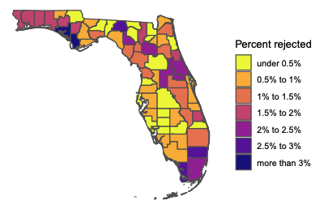

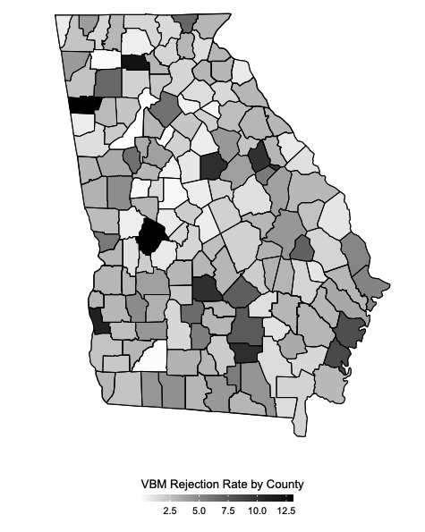

Vote By Mail Rejection Rates in [Florida](https://electionscience.clas.ufl.edu/files/2020/04/Baringer_Herron_Smith_VBM_FL.pdf) and [Georgia](https://electionscience.clas.ufl.edu/files/2020/05/GA_Venmo.pdf) Counties

[^1]: It is possible some states had a more rapid expansion of vote by mail in non-federal elections.
[^2]: This figure comes from table 3 columns 4-6. It’s important to note that the difference in difference model they use might slightly understate the *level* of change if counties that did not switch to 100% vote by mail nevertheless increased their mail voting rate over time.
[^3]: It’s important to note that many univerisal vote by mail jurisdictions have some in-person polling places and it can be [common](https://twitter.com/jon_m_rob/status/1263836822196625408) for people return mailed ballots in person.
[^4]: One way to test this empirically would be to check if there are heterogeneous effects of universal VBM by previous usage of VBM. In other words, test if counties had lower rates of VBM before universal VBM had different turnout effects compared to counties with high rates of VBM before universal VBM.
[^5]: While this is almost certainly an overestimate due to nonvoters lying about trying to vote, a substantial number of mail voters ballots are rejected by election officials.
[^6]: For instance, someone who had the wrong address on file may have not received a mail ballot may correct it in the future. Voters who make mistakes on their ballot (mailing it too late or not signing it correctly) may be notified by election officials about the problem so they can correct it in the future.
[^7]: It’s hard to directly compare this to counterfactual in-person voting. It’s likely that some in-person voters are turned away who could of voted, but unlike mail ballots, records aren’t produced for those who try to vote in-person and fail.
[^8]: According to the CPS, 8% of Georgia voters cast ballots by mail and 31% of Florida voters did.